# STA100 Lab4

Po

4/20/2021

# Lab 2 Assignment (Lab projects?)

1. Go though `Lab2Assignment.pdf` Lab2Assignment.pdf (Yup, 2 at middle.)
2. Download and open `Lab2Assignment.Rmd` Lab2Assignment.Rmd in RStudio and run codes inside.
3. Download, open `LabAssignment2_otg.Rmd` Lab2Assignment_otg.Rmd and save as a new Rmd file for your Lab Assignment submission. Knit this Rmd file to see if you can make a html, pdf or words. You should be able to get a document. If you couldn’t, just use RStudio Cloud or the Binder RStudio in the lab note homepage. Po likes RStudio. Everything you need is on the cloud.
4. Run/add/edit/delete the codes in your own copy of `Lab2Assignment_otg.Rmd` and add/edit/delete some writings. Knit to see how the .pdf looks like.
5. Tidy up the codes and writings. Knit and submit!

# R and RStudio continue

Follow the below instructions to make yourself comfortable in using R/RStudio for statistical/scientific computing.

### Working directory

Working directory is the default folder in which files are saved and read.

- In the **Files** tab, find/create a folder for your STA100 work. Click **More** then **Set As Working Directory**.
- Open the R script you worked on last week. Run the codes.
- Working directory is not persistent after you you close the R/RStudio. Remember to set working directory each time you open a R/RStudio.

### Read data

R has many built-in functions to read data, for example, `read.table()`.

```r
lab2_data <- read.table("iris.data", sep = ",")
```

Good job! You have load the data into R. Look the the **Environment** tab. You can see we have just created a variable named `lab2_data`. Click on it and peek what is inside!

- Ops, what are the columns `V1`, `V2`, `V3`, `V4` and `V5`? Open then text file `iris.names` and read the description! They are actually

  ```
     1. sepal length in cm
     2. sepal width in cm
     3. petal length in cm
     4. petal width in cm
     5. class:
        -- Iris Setosa
        -- Iris Versicolour
        -- Iris Virginica
  ```

  Rename the columns:

```r
colnames(lab2_data) <- c("sepal_length", "sepal_width", "petal_length", "petal_width", "class")
```

Check `lab2_data` again to see the change.

- Put the codes

```r
lab2_data <- read.table("iris.data", sep = ",")
colnames(lab2_data) <- c("sepal_length", "sepal_width", "petal_length", "petal_width", "class")
```

into your R script and save it! Now you can shut down your computer and go out to enjoy the sunshine! See you all next week!

### Let’s do some statistics!

- To access a column in a data frame, for example the `sepal_length` column in `lab2_data`, type `lab2_data$sepal_length` or `lab2_data["sepal_length"]`.
- R has lots of built-in functions for statistics. For example, the function `summary()` show you:

  ```r
  summary(lab2_data)
  ```

  ```
  ##   sepal_length    sepal_width     petal_length    petal_width       class
  ##  Min.   :4.300   Min.   :2.000   Min.   :1.000   Min.   :0.100   Length:150
  ##  1st Qu.:5.100   1st Qu.:2.800   1st Qu.:1.600   1st Qu.:0.300   Class :character
  ##  Median :5.800   Median :3.000   Median :4.350   Median :1.300   Mode  :character
  ##  Mean   :5.843   Mean   :3.054   Mean   :3.759   Mean   :1.199
  ##  3rd Qu.:6.400   3rd Qu.:3.300   3rd Qu.:5.100   3rd Qu.:1.800
  ##  Max.   :7.900   Max.   :4.400   Max.   :6.900   Max.   :2.500
  ```

- Let’s compute the mean and standard deviation of “sepal length” with functions `median`, `mean()` and `sd()`:

  ```r
  median(lab2_data$sepal_length)
  ```

  ```
  ## [1] 5.8
  ```

  ```r
  mean(lab2_data$sepal_length)
  ```

  ```
  ## [1] 5.843333
  ```

  ```r
  sd(lab2_data$sepal_length)
  ```

  ```
  ## [1] 0.8280661
  ```

- Let’s plot a histogram.

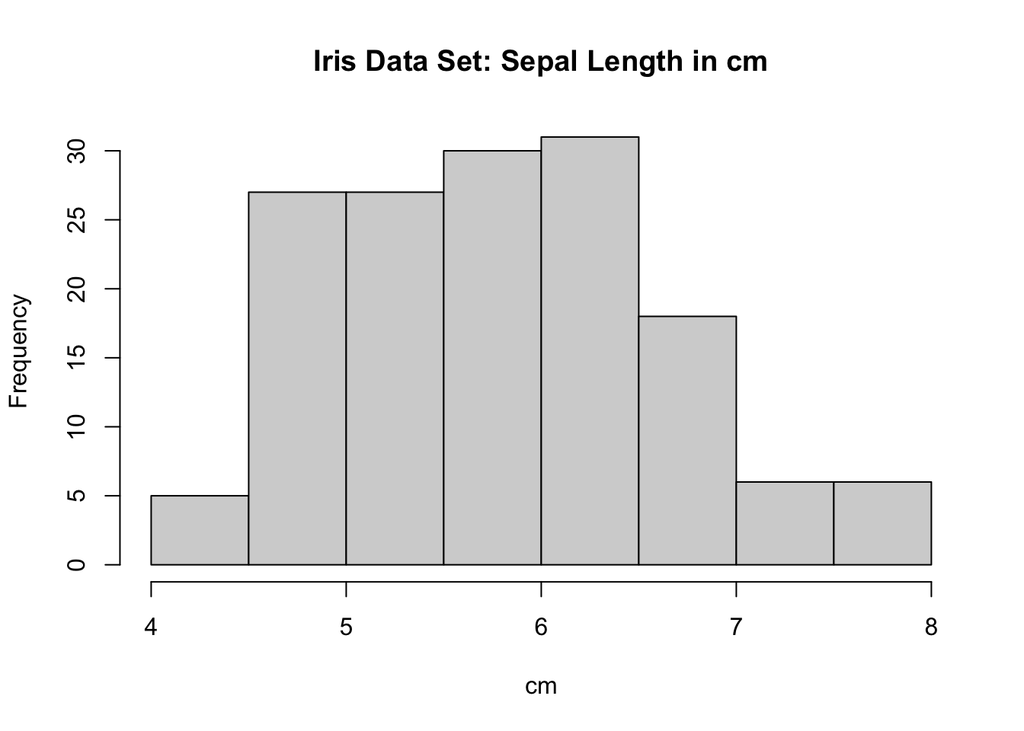

```r
hist(lab2_data$sepal_length,
     main = "Iris Data Set: Sepal Length in cm",
     xlab = "cm")
```

- Let’s standardize the sepal length

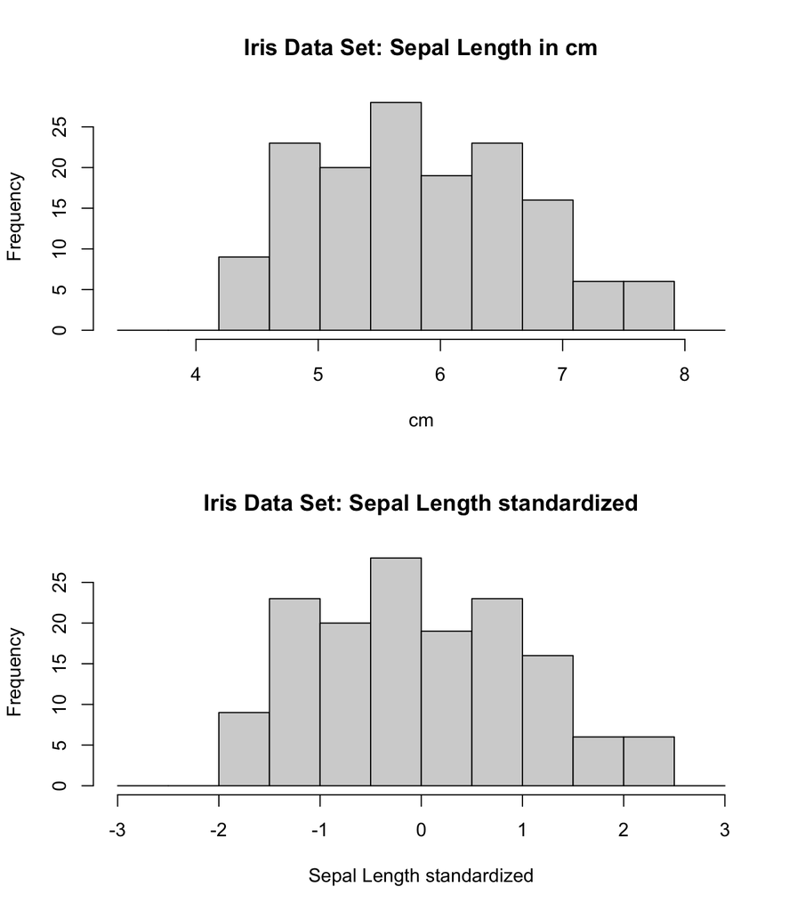

```r
mu <- mean(lab2_data$sepal_length)
sigma <- sd(lab2_data$sepal_length)
standardized_sepal_length <- (lab2_data$sepal_length - mu)/sigma

par(mfrow=c(2,1))
hist(lab2_data$sepal_length,
     breaks = seq(mu-3*sigma, mu+3*sigma,length.out=13),
     main = "Iris Data Set: Sepal Length in cm",
     xlab = "cm")
hist(standardized_sepal_length,
     breaks = seq(-3, 3, length.out=13),
     main = "Iris Data Set: Sepal Length standardized",
     xlab = "Sepal Length standardized")
```

### Help/Documentation

Read the R Documentation of the functions you learn today. Enter the following codes, one by one, and read the corresponding documentation/help in the **Help** tab.

```r
?read.table
```

```r
?colnames
```

```r
?summary
```

```r
?median
```

```r
?mean
```

```r
?sd
```

```r
?hist
```

```r
?par
```

How Po knows all those built-in functions in R?

- Way 1: Google it
- Way 2: Read R Help/Documentation

> Give a man a fish and you feed him for a day; Teach a man to fish and you feed him for a lifetime.

| Po | Codes in labs | Google | R Documentation |
| --- | --- | --- | --- |
| Fisherman | Fish | Fish Rod | Sea |

#### More R tutorial

- Interactive R course lessons **swirl** https://swirlstats.com/students.html

  Install **swirl** with the following commands.

  ```r
  # If you haven't installed the swirl package yet
  install.packages("swirl")
  library(swirl)
  install_course_github("swirldev", "R_Programming_E")
  ```

  After **swirl** is installed (you only need to do it once), you can start/resume the R tutorial with the commands:

  ```r
  library(swirl)
  swirl()
  ```

  Schedule some time to go though all the lessons by yourself! Almost all of the R codes you need to know are here in those lessons.
- If you prefer more static readings (Po did read them to learn R!):
  - R for Beginners https://cran.r-project.org/doc/contrib/Paradis-rdebuts_en.pdf
  - An Introduction to R https://cran.r-project.org/doc/manuals/r-release/R-intro.pdf
- If you like RStudio’s data science things,
  - R for Data Science https://r4ds.had.co.nz/
  - RStudio Primer https://rstudio.cloud/learn/primers/